# Afternoon work

Derek Corcoran

2024-02-24

# Packages used

Load packages to be used

```r
# For data wrangling
library(tidyverse)
# for spatial data
library(terra)
library(sf)
# To download spatial data
library(geodata)
# for spatial plots
library(tidyterra)
# for reading excel files
library(readxl)
# for nice tables
library(kableExtra)
# For improving naming
library(janitor)
# For getting habitat proportion
library(SpatioTemporalCont)
# For download links
library(downloadthis)
# For the models
library(sdmTMB)
library(sdmTMBextra)
# For distance estimations
library(gdistance)
# For plots
library(ggplot2)
```

# Grassland continuity in sampled areas

```r
coordinates <- read_excel("ExampleData/All Fields GPS coordinates.xlsx", skip = 1)

Coordinates_a <- coordinates[, 1:3] |>
    janitor::clean_names()
colnames(Coordinates_a) <- stringr::str_sub(colnames(Coordinates_a), end = -3)

Coordinates_a$type <- "Grassland"

Coordinates_b <- coordinates[, 5:7] |>
    janitor::clean_names()

colnames(Coordinates_b) <- stringr::str_sub(colnames(Coordinates_b), end = -3)

Coordinates_b$type <- "Conservation agriculture"

Coordinates_c <- coordinates[, 9:11] |>
    janitor::clean_names()

colnames(Coordinates_c)[1] <- stringr::str_sub(colnames(Coordinates_c)[1],
    end = -3)

colnames(Coordinates_c)[2:3] <- stringr::str_sub(colnames(Coordinates_c)[2:3],
    end = -4)

Coordinates_c$type <- "Conventional agriculture"

coordinates <- list(Coordinates_a, Coordinates_b, Coordinates_c) |>
    purrr::reduce(dplyr::bind_rows) |>
    tidyr::separate(coordinates_latitude_longitude, into = c("lat", "lon"),
        sep = ",") |>
    dplyr::mutate(lat = as.numeric(lat), lon = as.numeric(lon)) |>
    dplyr::mutate(location_code = stringr::str_replace_all(location_code,
        "Ø", "oe")) |>
    dplyr::mutate(location_code = stringr::str_replace_all(location_code,
        "Å", "aa")) |>
    dplyr::mutate(location_code = stringr::str_replace_all(location_code,
        "Æ", "ae")) |>
    dplyr::mutate(location_code = janitor::make_clean_names(location_code,
        allow_dupes = T)) |>
    dplyr::mutate(location_code = stringr::str_remove_all(location_code, "ca_"),
        location_code = stringr::str_remove_all(location_code, "k_"), location_code = stringr::str_remove_all(location_code,
            "_"))

coordinates <- coordinates[complete.cases(coordinates), ]
```

## Getting habitat proportion with given locations

First we will read in the spatRaster used for the habitat proportion calculation, the full resolution map can be downloaded in this [link](https://envs.au.dk/en/research-areas/society-environment-and-resources/land-use-and-gis/basemap/basemap04-geotiff-for-download)

```r
data("Landuse_DK")
Landuse <- terra::unwrap(Landuse_DK)
```

## Extract proportion for the points

```r
coordinates_sf <- terra::vect(coordinates, geom = c("lon", "lat"), crs = "epsg:4326") |>
    terra::project(terra::crs(Landuse))
```

The landuse and points can be seen in the following figure

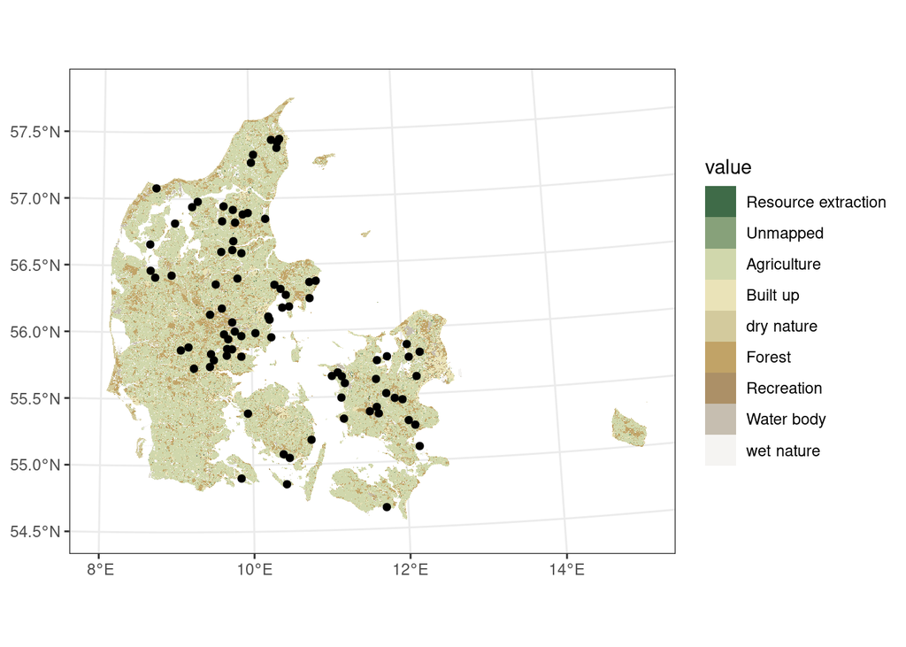

## Extract proportion of grasland from points

```r
GrasslandProp <- SpatioTemporalCont::summarise_polygons(Rast = Landuse, Polygons = coordinates_sf,
    Vars = "dry nature", dist = 2000, type = "Both")
```

| dry nature |
| --- |
| 0.0312000 |
| 0.1876997 |
| 0.0043764 |
| 0.0000000 |
| 0.0175439 |
| 0.0276243 |
| 0.0306452 |
| 0.0079618 |
| 0.0192308 |
| 0.0087789 |
| 0.0091827 |
| 0.0520416 |
| 0.0116580 |
| 0.0335463 |
| 0.0240577 |
| 0.0176000 |
| 0.0076220 |
| 0.0098684 |
| 0.0127694 |
| 0.0333988 |
| 0.0069541 |
| 0.0179211 |
| 0.0240192 |
| 0.0971338 |
| 0.0122549 |
| 0.0207171 |
| 0.0713202 |
| 0.0192000 |
| 0.0341615 |
| 0.0511591 |

[output cut: 55 more lines]

## Importing genetic diversity

```r
test_data_genetic_diversity_workshop2024 <- read_table("ExampleData/test_data_genetic_diversity_workshop2024.txt") |>
    dplyr::mutate(Site = janitor::make_clean_names(Site, allow_dupes = T),
        Site = stringr::str_remove_all(Site, "_"), Site = stringr::str_replace_all(Site,
            "lss", "les")) |>
    dplyr::select(Site, pi) |>
    dplyr::rename(location_code = Site) |>
    dplyr::full_join(coordinates)
```

Now we have joined most of the sites, and we will now filter to only sites with genetic diversity values, that are grasslands and have coordinates

```r
clean_data <- test_data_genetic_diversity_workshop2024 |>
    dplyr::filter(!is.na(pi), type == "Grassland", !is.na(lat))
```

Lets look at genetic diversity in the map

```r
clean_data_sf <- terra::vect(clean_data, geom = c("lon", "lat"), crs = "epsg:4326") |>
    terra::project(terra::crs(Landuse))
```

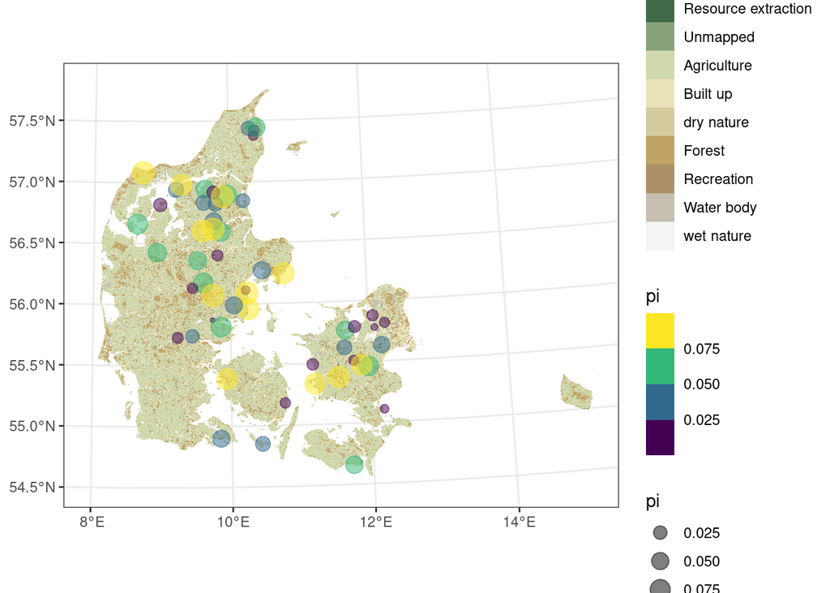

## Genetic distance

First we generate a table of ids for the site

```r
SiteID <- data.frame(location_code = c("aaRJ", "BIJ", "DoeJ", "DSJ", "FUR",
    "GEJ", "GUS", "HHJ", "JEJ", "JHJ", "KoeJ", "LVJ", "MSJ", "NOJ", "SBJ",
    "SKJ", "ULJ", "UTJ", "VAJ"), ID = 1:19) |>
    dplyr::mutate(location_code = stringr::str_to_lower(location_code)) |>
    dplyr::left_join(clean_data)
```

We also build a spatial version of this to get the spatial distance

```r
SiteID_sf <- terra::vect(SiteID, geom = c("lon", "lat"), crs = "epsg:4326") |>
    terra::project(terra::crs(Landuse))

CoordSites <- terra::geom(SiteID_sf)[, c(3, 4)]
```

Now lets combine this with the actual Fst data

```r
Fst <- read_table("ExampleData/EntNic_fst_data_old.tsv", col_names = FALSE) |>
    tidyr::separate(X1, into = c("from", "to")) |>
    dplyr::rename(Fst = X2) |>
    dplyr::mutate_all(as.numeric) |>
    dplyr::group_by(from, to) |>
    dplyr::summarise(Fst = mean(Fst))
```

And now add the euclidean distance

```r
euc_dist <- distance(SiteID_sf) |>
    as.matrix() |>
    GeNetIt::dmatrix.df() |>
    right_join(Fst)
```

An now we can plot the distances among them

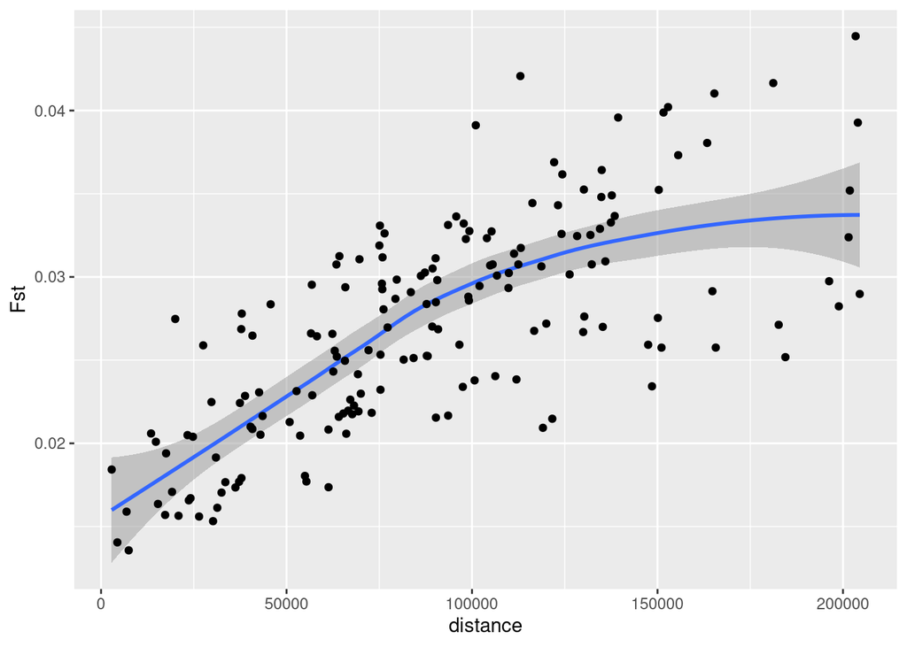

### Building transition distances

We will build transistion distances based on 2500 meters and 500 meters for grasslands.

```r
Grassland500 <- SpatioTemporalCont::calculate_prop(Rast = Landuse, Radius = 500,
    Vars = c("dry nature", "Forest", "wet nature", "Agriculture"))

Grassland500 <- Grassland500["dry nature"] * 2 + Grassland500["wet nature"] +
    Grassland500["Forest"] * 0.8 + Grassland500["Agriculture"] * 0.2

Grassland500 <- Grassland500 + 0.001
Grassland500[is.na(Grassland500)] <- 0.001

Grassland500 <- terra::aggregate(Grassland500, fact = 5, cores = 4)

Grassland2500 <- SpatioTemporalCont::calculate_prop(Rast = Landuse, Radius = 2500,
    Vars = c("dry nature", "Forest", "wet nature", "Agriculture"))
```

```
##
|---------|---------|---------|---------|
=========================================
```

```r
Grassland2500 <- Grassland2500["dry nature"] * 2 + Grassland2500["wet nature"] +
    Grassland2500["Forest"] * 0.8 + Grassland2500["Agriculture"] * 0.2

Grassland2500 <- Grassland2500 + 0.001
Grassland2500[is.na(Grassland2500)] <- 0.001

Grassland2500 <- terra::aggregate(Grassland2500, fact = 5, cores = 4)
```

We can plot both together

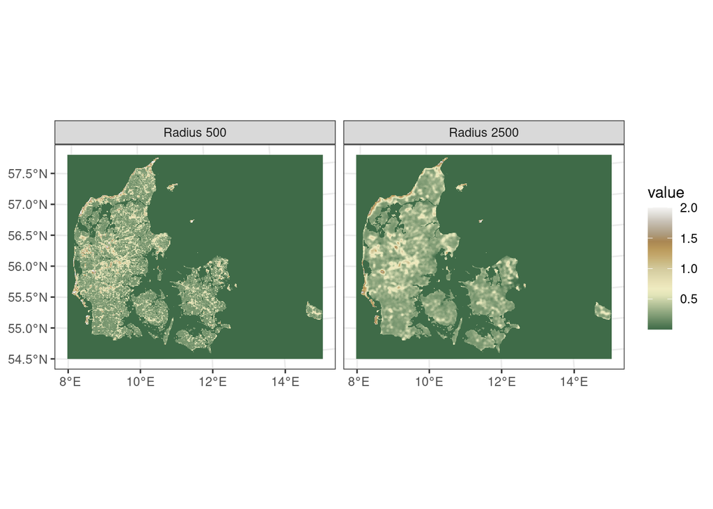

To build the conductivity layers we use gdistance

```r
tr.cost500 <- gdistance::transition(raster::raster(Grassland500), transitionFunction = mean,
    directions = 4)
tr.cost500 <- gdistance::geoCorrection(tr.cost500, type = "c", multpl = FALSE)


saveRDS(tr.cost500, "tr.cost500.rds")
```

```r
tr.cost2500 <- gdistance::transition(raster::raster(Grassland2500), transitionFunction = mean,
    directions = 4)
tr.cost2500 <- gdistance::geoCorrection(tr.cost2500, type = "c", multpl = FALSE)

saveRDS(tr.cost2500, "tr.cost2500.rds")
```

Check some fast graphical outputs first with euclidean distance

```r
Neighbours <- terra::delaunay(clean_data_sf, as.lines = T)
terra::writeVector(Neighbours, "Neighbours.shp", overwrite = T)
```

and then with shortest paths

```r
Lines500 <- list()

for (i in 1:nrow(Neighbours)) {
    Temp <- as.matrix(as.data.frame(terra::intersect(clean_data_sf, Neighbours[i,
        ]), geom = "XY")[c("x", "y")])
    Lines500[[i]] <- terra::vect(sf::st_as_sf(gdistance::shortestPath(tr.cost500,
        origin = Temp[1, ], goal = Temp[2, ], output = "SpatialLines")))
    terra::crs(Lines500[[i]]) <- terra::crs(Neighbours)
}

Lines2500 <- list()

for (i in 1:nrow(Neighbours)) {
    Temp <- as.matrix(as.data.frame(terra::intersect(clean_data_sf, Neighbours[i,
        ]), geom = "XY")[c("x", "y")])
    Lines2500[[i]] <- terra::vect(sf::st_as_sf(gdistance::shortestPath(tr.cost2500,
        origin = Temp[1, ], goal = Temp[2, ], output = "SpatialLines")))
    terra::crs(Lines2500[[i]]) <- terra::crs(Neighbours)
}

Lines500 <- Lines500 |>
    purrr::reduce(rbind)
terra::writeVector(Lines500, "Lines500.shp", overwrite = T)

Lines2500 <- Lines2500 |>
    purrr::reduce(rbind)
terra::writeVector(Lines2500, "Lines2500.shp", overwrite = T)
```

Now we plot the shortest path, vs euclidean

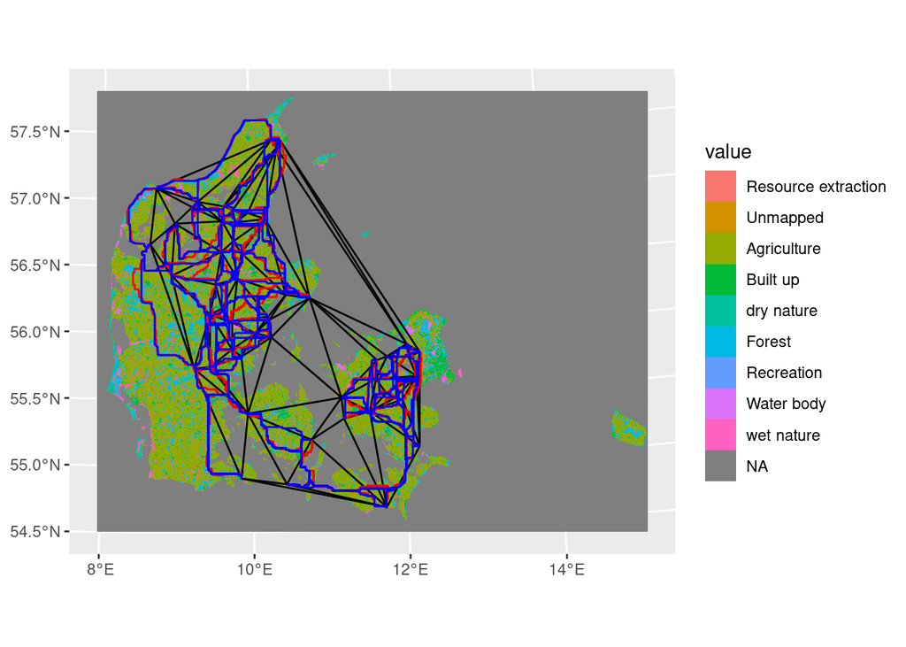

```r
Landuse <- terra::unwrap(Landuse_DK)
Lines500 <- terra::vect("Lines500.shp")
Lines2500 <- terra::vect("Lines2500.shp")
Neighbours <- terra::vect("Neighbours.shp")


ggplot() + geom_spatraster(data = Landuse) + geom_spatvector(data = Neighbours) +
    geom_spatvector(data = Lines500, color = "red") + geom_spatvector(data = Lines2500,
    color = "blue")
```

```r
Landuse <- terra::unwrap(Landuse_DK)
euc_dist$least_cost500 <- NA
euc_dist$least_cost2500 <- NA

for (i in 1:nrow(euc_dist)) {
    Temp <- terra::vect(sf::st_as_sf(gdistance::shortestPath(tr.cost500, origin = CoordSites[euc_dist$from[i],
        ], goal = CoordSites[euc_dist$to[i], ], output = "SpatialLines")))
    terra::crs(Temp) <- terra::crs(Landuse)
    euc_dist$least_cost500[i] <- terra::perim(Temp)

    Temp <- terra::vect(sf::st_as_sf(gdistance::shortestPath(tr.cost2500, origin = CoordSites[euc_dist$from[i],
        ], goal = CoordSites[euc_dist$to[i], ], output = "SpatialLines")))
    terra::crs(Temp) <- terra::crs(Landuse)
    euc_dist$least_cost2500[i] <- terra::perim(Temp)
}

all_dist <- euc_dist
```

Now we can show the plot of the different distances

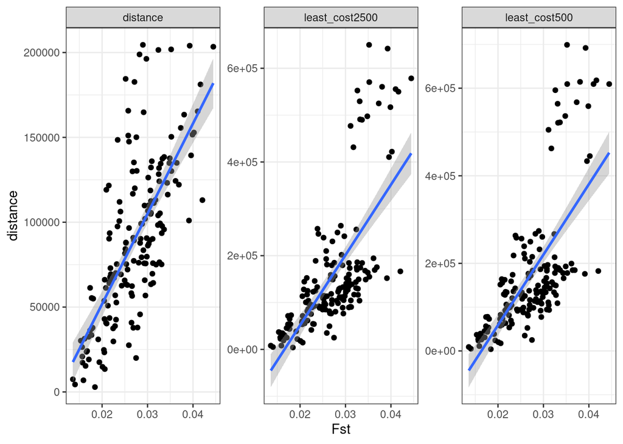

## Buidling the mesh

First we will take a look at a first option of a mesh

```r
Meshcoords <- terra::geom(clean_data_sf) |>
    as.data.frame()

bnd <- INLA::inla.nonconvex.hull(cbind(Meshcoords$x, Meshcoords$y), convex = -0.1)
mesh_inla <- fmesher::fm_mesh_2d(boundary = bnd, max.edge = c(8000, 50000))
mesh <- sdmTMB::make_mesh(Meshcoords, c("x", "y"), mesh = mesh_inla)
```

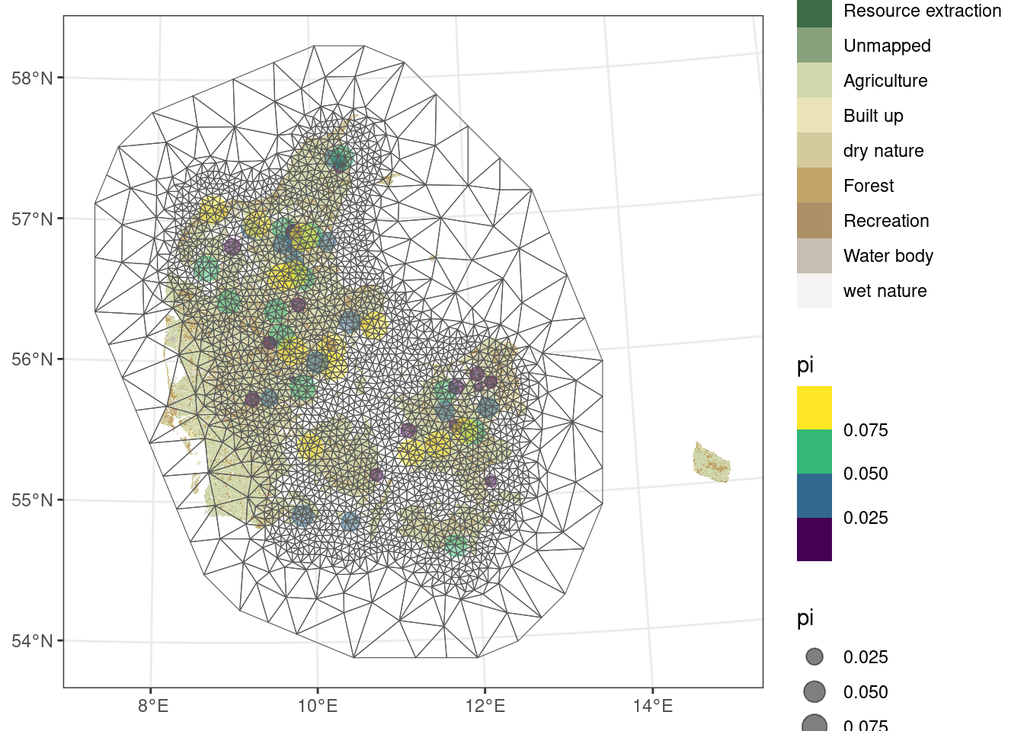

We should add a barrier, since we have the sea, for that we will download a polygon of Denmark, reproject it and transform it in to an sf object

```r
DK <- geodata::gadm("Denmark", level = 0, path = getwd()) |>
    terra::project(Landuse) |>
    sf::st_as_sf()
```

And now we add it to the mesh

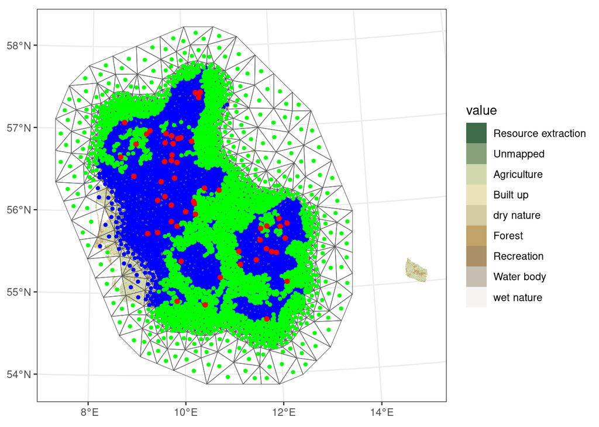

```r
bspde <- sdmTMBextra::add_barrier_mesh(mesh, DK, range_fraction = 0.1, plot = FALSE)
```